# Mood Disorder & Suicidality Risk Variable EDA

Sam A. Sievertsen

2025-01-14

# Exploratory Data Analysis (EDA) of variables to be included in the clustering of groups at potential risk for the development of mood disorders and suicidality in the ABCD dataset

The most up to date list of variables to be incorporated in the risk clustering, including their role, domain, details of each variable as it relates to the ABCD dataset, empirical justification for inclusion in the clustering, etc., can be found here.

Additionally, details regarding the incorporation of the sum adverse childhood experience (ACE) index and specific variables within it, as first recommended by [Hoffman et al., (2019)](https://www.sciencedirect.com/science/article/pii/S2352289518300821?via%3Dihub) and iterated upon by [Raney et al., (2022)](https://pmc.ncbi.nlm.nih.gov/articles/PMC9288265/) can be located here.

The following report contains information regarding the:

1. Integrity of the data
2. Assessment of outliers in the data + preliminary thoughts on how to address them
3. Skewness + appropriateness of the mean as the measure of central tendency for continuous variables
4. Shape of each variables’ distribution
5. A summary of the overall availability of variables of interest to the current study

## 1. Define the N, percent, and range of risk variables of interest at the baseline assessment timepoint

[output not shown]

## 2. Visually and Quantitatively Assess for any Outliers in the Data

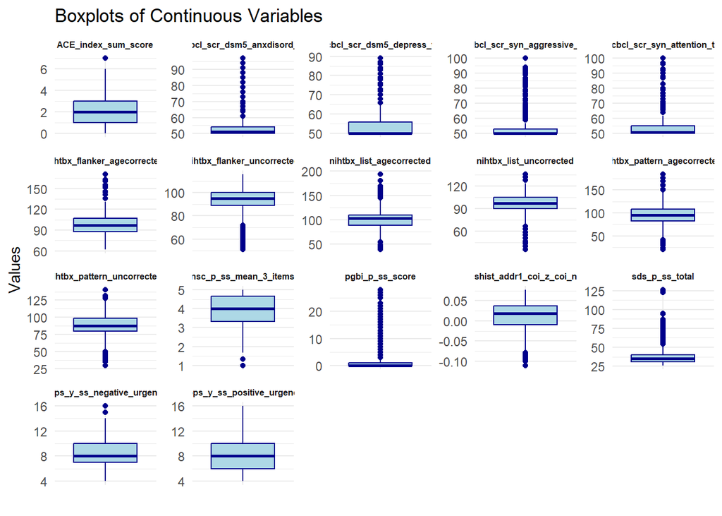

From the boxplots for continuous variables, it is evident that some of the NIHTB scores are likely out of the expected range. While no guidelines within the [overview of the ABCD baseline neurocognition battery](https://www.sciencedirect.com/science/article/pii/S1878929317302384?via%3Dihub#tbl0005) or mention of the extraneously high/low scores within [current release notes](https://wiki.abcdstudy.org/release-notes/non-imaging/neurocognition.html#nih-toolbox-cognition) could be located, it is likely that winsorization or other outlier removal methods will need to be applied to handle values beyond the expected range.

Following review of the [NIH Toolbox (Cognition) Instrument Description](https://wiki.abcdstudy.org/release-notes/non-imaging/neurocognition.html#nih-toolbox-cognition) (see **“Notes and Special Considerations”**), it is noted by the neurocognitive working group that “For longitudinal analyses, we recommend using either uncorrected Scaled Scores or raw scores.” Following review of the distributions below, a tentative decision regarding which strategy to use will be chosen.

No other anomalous or outlier values are noteworthy.

## 3. Appropriateness of the Mean as a Measure of Central Tendency

Though proposed clustering methods herein do not have parametric assumptions, assessment of skewness provides information about the asymmetry of variable distributions, which may help identify variables with extreme outliers or long tails. Such variables can disproportionately influence cluster formation when using euclidean distances (as in k-prototypes for continuous variables), and thus it is important to examine them. The skewness values for continuous variables herein are as such:

Skewness Values for Continuous Variables

| Variable | Skewness |
| --- | --- |
| cbcl_scr_dsm5_depress_t | 1.95 |
| cbcl_scr_dsm5_anxdisord_t | 2.51 |
| cbcl_scr_syn_attention_t | 2.46 |
| cbcl_scr_syn_aggressive_t | 2.76 |
| pgbi_p_ss_score | 3.48 |
| upps_y_ss_negative_urgency | 0.28 |
| upps_y_ss_positive_urgency | 0.47 |
| sds_p_ss_total | 1.98 |
| reshist_addr1_coi_z_coi_nat | -0.78 |
| nsc_p_ss_mean_3_items | -0.89 |
| nihtbx_list_agecorrected | 0.29 |
| nihtbx_list_uncorrected | -0.54 |
| nihtbx_flanker_agecorrected | 0.45 |
| nihtbx_flanker_uncorrected | -1.00 |
| nihtbx_pattern_agecorrected | -0.21 |
| nihtbx_pattern_uncorrected | -0.19 |
| ACE_index_sum_score | 0.39 |

Results from the assessment of skewness values suggest that the only variable which may be problematically skewed is *pgbi_p_ss_score* (GBI Mania Sum Score, skewness = 3.48); though, it is expected that the variable would be positively skewed given [low rates of mania in this age range](https://pmc.ncbi.nlm.nih.gov/articles/PMC8233426/).

As such, it is likely that no variable transformations are necessary, and downstream trends of this variable during clustering and subsequent frequentist analyses will just need to be monitored with this skew in mind.

## 4. Shape of Each Variables’ Distribution

The shape of the distribution for each continuous variable and frequency distribution of each categorical variable is outlined below, both in terms of summary statistics derived from and a graphical histogram with density overlay of relevant data:

Summary Statistics for Risk Model Variables

| Variable | Type | Mean | Median | SD | Min | Max | Levels | Frequencies |
| --- | --- | --- | --- | --- | --- | --- | --- | --- |
| cbcl_scr_dsm5_depress_t | Continuous | 53.6038786 | 50.00000000 | 5.73027710 | 50.00000000 | 89.00000000 | NA | NA |
| cbcl_scr_dsm5_anxdisord_t | Continuous | 53.4941821 | 51.00000000 | 6.12665736 | 50.00000000 | 97.00000000 | NA | NA |
| cbcl_scr_syn_attention_t | Continuous | 53.9059865 | 51.00000000 | 6.16900969 | 50.00000000 | 100.00000000 | NA | NA |
| cbcl_scr_syn_aggressive_t | Continuous | 52.8355818 | 50.00000000 | 5.53506393 | 50.00000000 | 100.00000000 | NA | NA |
| pgbi_p_ss_score | Continuous | 1.3026138 | 0.00000000 | 2.77304249 | 0.00000000 | 28.00000000 | NA | NA |
| upps_y_ss_negative_urgency | Continuous | 8.4895737 | 8.00000000 | 2.64549540 | 4.00000000 | 16.00000000 | NA | NA |
| upps_y_ss_positive_urgency | Continuous | 7.9947657 | 8.00000000 | 2.95847764 | 4.00000000 | 16.00000000 | NA | NA |
| sds_p_ss_total | Continuous | 36.5378116 | 35.00000000 | 8.24448863 | 26.00000000 | 126.00000000 | NA | NA |
| reshist_addr1_coi_z_coi_nat | Continuous | 0.0116627 | 0.01897914 | 0.03421424 | -0.11061431 | 0.07690442 | NA | NA |
| nsc_p_ss_mean_3_items | Continuous | 3.8886875 | 4.00000000 | 0.97578783 | 1.00000000 | 5.00000000 | NA | NA |
| nihtbx_list_agecorrected | Continuous | 100.5530072 | 103.00000000 | 14.78639146 | 39.00000000 | 194.00000000 | NA | NA |
| nihtbx_list_uncorrected | Continuous | 96.6488948 | 97.00000000 | 12.08780767 | 36.00000000 | 136.00000000 | NA | NA |
| nihtbx_flanker_agecorrected | Continuous | 95.4255740 | 97.00000000 | 13.67676894 | 62.00000000 | 171.00000000 | NA | NA |
| nihtbx_flanker_uncorrected | Continuous | 93.9986513 | 95.00000000 | 9.14626840 | 51.00000000 | 116.00000000 | NA | NA |
| nihtbx_pattern_agecorrected | Continuous | 93.7802001 | 95.00000000 | 22.07325502 | 20.00000000 | 185.00000000 | NA | NA |
| nihtbx_pattern_uncorrected | Continuous | 88.0570146 | 88.00000000 | 14.58620182 | 30.00000000 | 140.00000000 | NA | NA |
| ACE_index_sum_score | Continuous | 1.9555106 | 2.00000000 | 1.36387655 | 0.00000000 | 7.00000000 | NA | NA |
| famhx_ss_momdad_ma_p | Categorical | NA | NA | NA | NA | NA | 0, 1 | 10739, 552 |
| kbi_p_c_bully | Categorical | NA | NA | NA | NA | NA | 1, 2 | 1813, 10050 |
| ksads_bully_raw_26 | Categorical | NA | NA | NA | NA | NA | 0, 1 | 9594, 2083 |
| family_history_depression | Categorical | NA | NA | NA | NA | NA | 0, 1 | 7722, 3628 |
| Criminal Household Member | Categorical | NA | NA | NA | NA | NA | 0, 1 | 8323, 3545 |
| Emotional neglect | Categorical | NA | NA | NA | NA | NA | 0, 1 | 11147, 721 |
| Household Depression or SI | Categorical | NA | NA | NA | NA | NA | 0, 1 | 5335, 6533 |
| Household substance abuse | Categorical | NA | NA | NA | NA | NA | 0, 1 | 5668, 6200 |
| Mother treated violently | Categorical | NA | NA | NA | NA | NA | 0, 1 | 8070, 3798 |
| Parental separation or divorce | Categorical | NA | NA | NA | NA | NA | 0, 1 | 10227, 1641 |
| Physical abuse | Categorical | NA | NA | NA | NA | NA | 0, 1 | 11773, 95 |
| Physical neglect | Categorical | NA | NA | NA | NA | NA | 0, 1 | 11289, 579 |
| Sexual Abuse | Categorical | NA | NA | NA | NA | NA | 0, 1 | 11772, 96 |

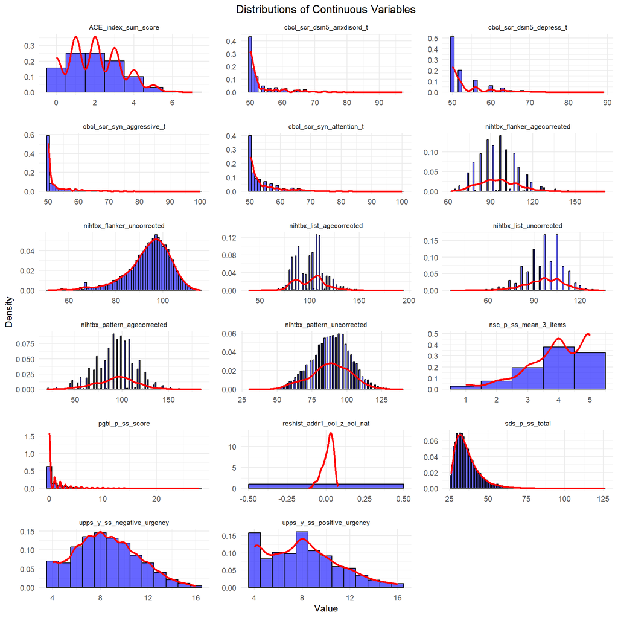

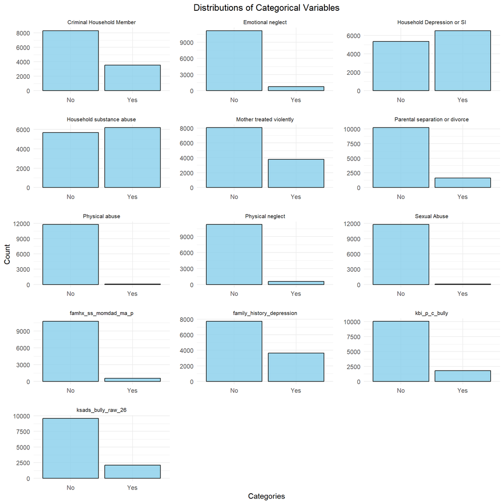

Distributions of continuous variables and rates of categorical variables (including the individual ACEs comprising the sum ACE index score) are shown above. While some previously mentioned variables exhibit noticeable skew, no problematic distributions are notable here.

This decision is tentative, however, and subject to future review/change in the event new information comes to light.

## 5. Overall Availability of Risk Model Variables for Clustering

When looking across all relevant risk variables in the dataset, 9,153 (77.12%) subjects have complete (i.e., fully reported, non-missing) data.